# NMF_demo

### 2) 每个群中的 mean exp

```r
mean.fxn = function(x, pseudocount.use=1, base=2) {
  return(log(x = rowMeans(x = expm1(x = x)) + pseudocount.use, base = base))
}
rsM=NULL;
for(i in levels(pbmc.nmf)){
  cells.1 = WhichCells(pbmc.nmf, idents = i)
  rs0 = mean.fxn(dat[features, cells.1, drop=F])
  rsM = cbind(rsM, rs0)
  print(dim(rsM))
}
```

```
## [1] 108   1
## [1] 108   2
## [1] 108   3
## [1] 108   4
## [1] 108   5
## [1] 108   6
## [1] 108   7
## [1] 108   8
## [1] 108   9
## [1] 108  10
## [1] 108  11
```

```r
colnames(rsM)=paste0("Cluster",levels(pbmc.nmf))
head(rsM)
```

```
##         Cluster0   Cluster1   Cluster2  Cluster3   Cluster4  Cluster5  Cluster6
## IL7R   0.5783467 2.97218212 0.79030927 2.7901951 2.65087165 3.3609040 0.5133748
## S100A8 6.4833172 0.54379009 0.48324592 0.2794916 0.50299391 0.5752853 3.2575690
## CD79A  0.2300565 0.30918779 4.55617698 0.1203183 0.27274330 0.2712897 0.2403736
## GZMB   0.2565375 0.14356850 0.19463312 2.1670096 0.19217687 0.2363497 0.3053534
## PF4    0.1351051 0.03487235 0.07499719 0.1609550 0.01904058 0.0000000 0.3824003
## MS4A7  1.2618183 0.09782055 0.43514025 0.1232816 0.12966611 0.1445432 2.9259239
##          Cluster7   Cluster8  Cluster9 Cluster10
## IL7R   2.69812613 0.84073909 0.9562834 0.4354341
## S100A8 0.45948327 0.55654875 2.6684399 1.9170040
## CD79A  0.79957323 0.11260199 0.6478446 0.1044942
## GZMB   0.20584260 5.65870171 2.7392979 1.1244498
## PF4    0.01589696 0.00000000 0.2130774 7.2228179
## MS4A7  0.03116309 0.04864571 0.5776897 0.2931964
```

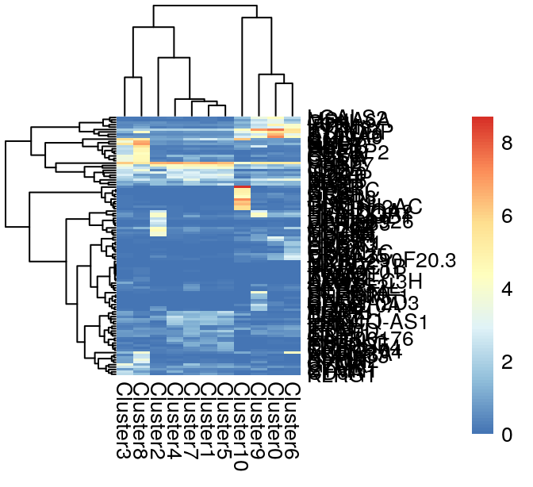

```r
p =pheatmap(rsM, border_color = NA, clustering_method = "ward.D2")
```

```r
# 获取聚类后的基因顺序
row_cluster = cutree(p$tree_row,k=6)
# 对聚类后的数据进行重新排序
newOrder = rsM[p$tree_row$order,]
#newOrder[,ncol(newOrder)+1]= row_cluster[match(rownames(newOrder),names(row_cluster))]
#colnames(newOrder)[ncol(newOrder)]="Cluster"
# 查看重新排序后的数据
head(newOrder)
```

```
##        Cluster0  Cluster1  Cluster2  Cluster3  Cluster4   Cluster5 Cluster6
## LGALS2 4.296763 0.2194642 0.2065756 0.1187146 0.2786202 0.06569327 2.249148
## MS4A6A 3.232930 0.1824591 0.1188825 0.1281771 0.1592001 0.08310864 1.390507
## GRN    3.199818 0.2318531 0.6841047 0.4564896 0.3730964 0.48195845 2.001191
## FCN1   4.797550 0.5578412 0.5910947 0.4149588 0.5384594 0.65455950 4.007145
## IFITM3 2.922208 0.2003130 0.2609213 0.4901171 0.4235872 0.39331258 4.166580
## LYZ    7.597019 1.9862370 2.0864374 1.9135665 1.9784074 2.15867502 5.570402
##         Cluster7   Cluster8 Cluster9 Cluster10
## LGALS2 0.1706343 0.14313213 3.487993  1.501095
## MS4A6A 0.1148936 0.08192313 2.268643  0.812377
## GRN    0.3579583 0.45463957 2.835850  1.458060
## FCN1   0.5144093 0.71581304 2.305610  1.018420
## IFITM3 0.1971241 1.08732299 2.540592  1.229016
## LYZ    2.0239575 1.95027818 6.967274  4.232046
```

```r
# 基因在每个cluster的最大值排序
rsM1=rev(sort(apply(rsM, 1, max)))
head(rsM1)
```

```
##     PPBP      LYZ   S100A9      PF4     NKG7    RPS27
## 8.699382 7.597019 7.223132 7.222818 6.956882 6.770116
```

```r
# plot(rsM1)


# 求交集
rs_inter = intersect( head(names(rsM1),n=50), head(names(rs3),n=50) )
length(rs_inter)
```

```
## [1] 47
```

```r
head(rs_inter)
```

```
## [1] "PPBP"   "LYZ"    "S100A9" "PF4"    "NKG7"   "RPS27"
```

```r
#DotPlot(pbmc.nmf, features = rs_inter, cluster.idents = T) + RotatedAxis()

# 聚类的结果
#DotPlot(pbmc.nmf, features = intersect( rownames(newOrder), head( names(rs3),n=90 ) ),
#          #rownames(newOrder),
#        cluster.idents = T) + RotatedAxis()

# 高表达比例 + 聚类后结果
#DotPlot(pbmc.nmf, features = intersect( rownames(newOrder), head( names(rs3),n=75 ) ),
#        cluster.idents = T) + RotatedAxis()
```

### 高表达mean + 聚类后结果

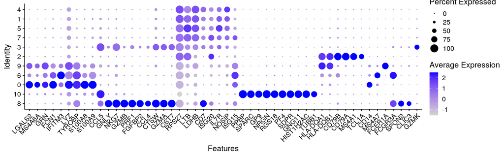

```r
DotPlot(pbmc.nmf, features = intersect( rownames(newOrder), head( names(rsM1),n=50 ) ),
        #rownames(newOrder),
        cluster.idents = T) + RotatedAxis()
```

# ref

- [Chen, YP., Yin, JH., Li, WF. et al. Single-cell transcriptomics reveals regulators underlying immune cell diversity and immune subtypes associated with prognosis in nasopharyngeal carcinoma. Cell Res 30, 1024–1042 (2020).](https://doi.org/10.1038/s41422-020-0374-x)
- [Dissecting the heterogeneity of the alternative polyadenylation profiles in triple-negative breast cancers](https://pubmed.ncbi.nlm.nih.gov/32929364/) Fig2(C) Cophenetic and dispersion metrics for NMF across 2 to 10 clusters with 50 runs suggest 4 stable subtypes.
- https://www.bilibili.com/video/BV1K3411x7J8/
- https://cloud.tencent.com/developer/article/1806266

== End ==